# **Multiple Regression**

## **Generating cars dataset**

the data set will be imported from a CSV file. To make the data unique, a random sample of size 30, without replacement, will be drawn from the data in the CSV file, and the data set will then be saved into a dataframe.

```python
import pandas as pd
from IPython.display import display, HTML

# read data from mtcars.csv data set.
cars_df_orig = pd.read_csv("https://s3-us-west-2.amazonaws.com/data-analytics.zybooks.com/mtcars.csv")

# randomly pick 30 observations from the data set to make the data set unique to you.
cars_df = cars_df_orig.sample(n=30, replace=False)

# print only the first five observations in the dataset.
print("Cars data frame (showing only the first five observations)\n")
display(HTML(cars_df.head().to_html()))
```

```
Cars data frame (showing only the first five observations)
```

|  | Unnamed: 0 | mpg | cyl | disp | hp | drat | wt | qsec | vs | am | gear | carb |
| --- | --- | --- | --- | --- | --- | --- | --- | --- | --- | --- | --- | --- |
| 6 | Duster 360 | 14.3 | 8 | 360.0 | 245 | 3.21 | 3.570 | 15.84 | 0 | 0 | 3 | 4 |
| 23 | Camaro Z28 | 13.3 | 8 | 350.0 | 245 | 3.73 | 3.840 | 15.41 | 0 | 0 | 3 | 4 |
| 15 | Lincoln Continental | 10.4 | 8 | 460.0 | 215 | 3.00 | 5.424 | 17.82 | 0 | 0 | 3 | 4 |
| 24 | Pontiac Firebird | 19.2 | 8 | 400.0 | 175 | 3.08 | 3.845 | 17.05 | 0 | 0 | 3 | 2 |
| 16 | Chrysler Imperial | 14.7 | 8 | 440.0 | 230 | 3.23 | 5.345 | 17.42 | 0 | 0 | 3 | 4 |

## **Scatterplot of miles per gallon against weight**

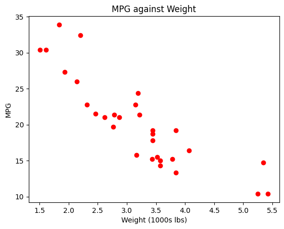

```python
import matplotlib.pyplot as plt

# create scatterplot of variables mpg against wt.
plt.plot(cars_df["wt"], cars_df["mpg"], 'o', color='red')

# set a title for the plot, x-axis, and y-axis.
plt.title('MPG against Weight')
plt.xlabel('Weight (1000s lbs)')
plt.ylabel('MPG')

# show the plot.
plt.show()
```

## **Scatterplot of miles per gallon against horsepower**

Scatterplot of the variables `miles per gallon` (mpg) and `horsepower` of the car (hp).

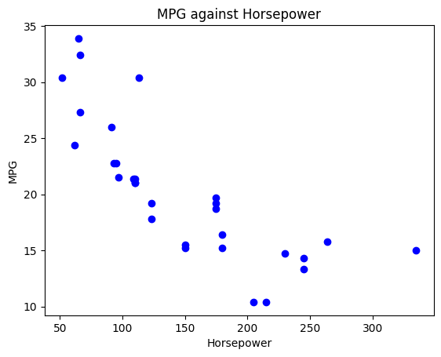

```python
import matplotlib.pyplot as plt

# create scatterplot of variables mpg against hp.
plt.plot(cars_df["hp"], cars_df["mpg"], 'o', color='blue')

# set a title for the plot, x-axis, and y-axis.
plt.title('MPG against Horsepower')
plt.xlabel('Horsepower')
plt.ylabel('MPG')

# show the plot.
plt.show()
```

## **Correlation matrix for miles per gallon, weight and horsepower**

calculate the correlation coefficient between the variables `miles per gallon` and `weight`. Also calculating the correlation coefficient between the variables `miles per gallon` and `horsepower`.  
The **corr** method of a dataframe returns the correlation matrix with the correlation coefficients between all variables in the dataframe.

```python
# create correlation matrix for mpg, wt, and hp.
# The correlation coefficient between mpg and wt is contained in the cell for mpg row and wt column (or wt row and mpg column).
# The correlation coefficient between mpg and hp is contained in the cell for mpg row and hp column (or hp row and mpg column).
mpg_wt_corr = cars_df[['mpg','wt','hp']].corr()
print(mpg_wt_corr)
```

```
          mpg        wt        hp
mpg  1.000000 -0.866318 -0.787577
wt  -0.866318  1.000000  0.665842
hp  -0.787577  0.665842  1.000000
```

## **Multiple regression model to predict miles per gallon using weight and horsepower**

multiple regression model with `miles per gallon` as the response variable, and `weight` and `horsepower` as predictor variables.  
The **ols** method in statsmodels.formula.api submodule returns all statistics for this multiple regression model.

```python
from statsmodels.formula.api import ols

# create the multiple regression model with mpg as the response variable; weight and horsepower as predictor variables.
model = ols('mpg ~ wt+hp', data=cars_df).fit()
print(model.summary())
```

```
                            OLS Regression Results
==============================================================================
Dep. Variable:                    mpg   R-squared:                       0.830
Model:                            OLS   Adj. R-squared:                  0.818
Method:                 Least Squares   F-statistic:                     66.05
Date:                Sat, 13 Apr 2024   Prob (F-statistic):           3.99e-11
Time:                        17:44:15   Log-Likelihood:                -70.174
No. Observations:                  30   AIC:                             146.3
Df Residuals:                      27   BIC:                             150.6
Df Model:                           2
Covariance Type:            nonrobust
==============================================================================
                 coef    std err          t      P>|t|      [0.025      0.975]
------------------------------------------------------------------------------
Intercept     37.2414      1.632     22.816      0.000      33.892      40.591
wt            -3.7842      0.655     -5.780      0.000      -5.127      -2.441
hp            -0.0334      0.009     -3.563      0.001      -0.053      -0.014
==============================================================================
Omnibus:                        4.291   Durbin-Watson:                   1.639
Prob(Omnibus):                  0.117   Jarque-Bera (JB):                3.201
Skew:                           0.796   Prob(JB):                        0.202
Kurtosis:                       3.166   Cond. No.                         573.
==============================================================================

Notes:
[1] Standard Errors assume that the covariance matrix of the errors is correctly specified.
```